# Sesión 10 - Datos Panel

Universidad Nacional de Colombia - Facultad de Ciencias Económicas

Ángel Rubio

2023-09-21

# Instalación y carga de paquetes

Para el tratamiento de series temporales, estimación de modelos y comprobación de resultados requerimos de las funciones de algunos paquetes no nativos.

El proceso se realizará con el comando “pacman”, el cual carga los paquetes ya instalados y descarga (para posteriormente cargar) los no instalados.

```r
pacman :: p_load(
  plm,        # Panel Linear models
  gplots,     # Motor gráfico
  haven,      # Importación de datos
  sandwich,   # Estimador de errores robustos
  stargazer,  # Presentación de resultados y tablas más estéticos
  lmtest,     # Herramientas de inferencia estadística
  tseries,    # Manejo de datos temporales
  wooldridge, # Bases de datos
  tidyverse,  # Manejo de datos y gráficos
  car         # Q-Q Plot!!
)
```

# 1. Educación a través del tiempo.

## 1.1 Descripción y preparación

Importaremos esta base de datos de una manera un tanto distinta, pues hay una base de datos proveniente del libro de Wooldridge.

```r
Education=read_dta("http://fmwww.bc.edu/ec-p/data/wooldridge/wagepan.dta")
attach(Education)
```

Visualicemos los datos.

```r
View(Education)
```

Lo compactamos como Panel Data Frame.

```r
panel.Education = pdata.frame(Education,
                              index = c("nr","year")) # Individuo y periodo
```

Podemos conocer algunas propiedades de este panel de datos. Una caracterísitica elemental son las dimensiones del panel de datos.

```r
pdim(panel.Education)
```

```
## Balanced Panel: n = 545, T = 8, N = 4360
```

Además, podemos conocer la variabilidad de los datos a través del tiempo, que es importante dadas algunas propiedades teóricas que deben cumplir los datos panel.

```r
pvar(panel.Education)
```

```
## no time variation:       nr black hisp educ
## no individual variation: year d81 d82 d83 d84 d85 d86 d87
```

Tambien es posible ver la distribución de la población.

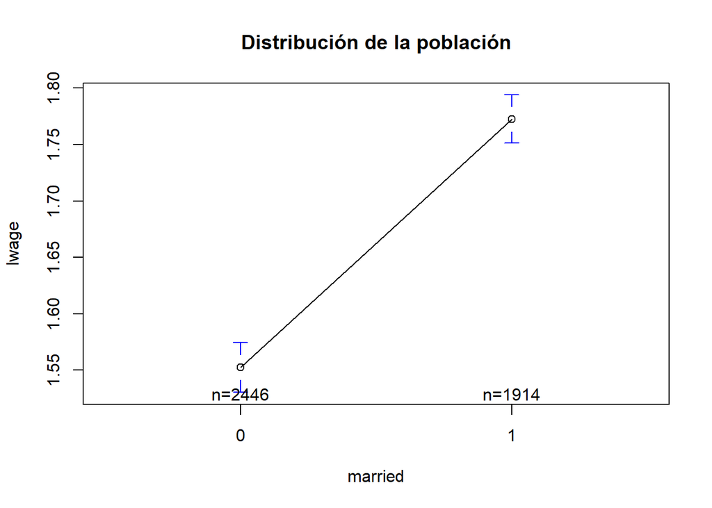

```r
plotmeans(lwage ~ married, main="Distribución de la población", data=panel.Education)
```

Para nuestra regresión incluiremos la experiencia al cuadrado para recoger los efectos marginales decrecientes de esta variable. Además añadiremos una dummy temporal.

```r
exper2 = expersq
panel.Education$yr = factor(panel.Education$year)#Una Dummy para cada año de la muestra
```

## 1.2 Estimación de modelos

Para este caso, consideraremos MCO Pooled, Efectos fijos, Efectos aleatorios y Primeras diferencias.

Posteriormente realizaremos el respectivo contraste.

- MCO Pooled: Esta estimaión ignora los posibles efectos que pueden ser inherentes a cada individuo, por lo que es una estimación sesgada.

```r
Pooled = plm(lwage~educ+black+hisp+exper+exper2+married+union+yr,
             data=panel.Education, model="pooling")
summary(Pooled)
```

```
## Pooling Model
##
## Call:
## plm(formula = lwage ~ educ + black + hisp + exper + exper2 +
##     married + union + yr, data = panel.Education, model = "pooling")
##
## Balanced Panel: n = 545, T = 8, N = 4360
##
## Residuals:
##     Min.  1st Qu.   Median  3rd Qu.     Max.
## -5.26573 -0.24838  0.03192  0.29475  2.52912
##
## Coefficients:
##                Estimate  Std. Error t-value  Pr(>|t|)
## (Intercept)  0.09205581  0.07827010  1.1761 0.2396074
## educ         0.09134979  0.00523738 17.4419 < 2.2e-16 ***
## black       -0.13923422  0.02357956 -5.9049 3.799e-09 ***
## hisp         0.01601951  0.02079714  0.7703 0.4411789
## exper        0.06723450  0.01369484  4.9095 9.467e-07 ***
## exper2      -0.00241170  0.00081995 -2.9413 0.0032860 **
## married      0.10825296  0.01568942  6.8997 5.962e-12 ***
## union        0.18246126  0.01715677 10.6349 < 2.2e-16 ***
## yr1981       0.05831998  0.03035363  1.9214 0.0547529 .
## yr1982       0.06277443  0.03321407  1.8900 0.0588251 .
## yr1983       0.06201174  0.03666013  1.6915 0.0908072 .
## yr1984       0.09046718  0.04009071  2.2566 0.0240849 *
## yr1985       0.10924626  0.04335248  2.5200 0.0117726 *
## yr1986       0.14195954  0.04642297  3.0580 0.0022421 **
## yr1987       0.17383339  0.04943305  3.5165 0.0004417 ***
## ---
## Signif. codes:  0 '***' 0.001 '**' 0.01 '*' 0.05 '.' 0.1 ' ' 1
##
## Total Sum of Squares:    1236.5
## Residual Sum of Squares: 1002.5
## R-Squared:      0.18928
## Adj. R-Squared: 0.18667
## F-statistic: 72.4588 on 14 and 4345 DF, p-value: < 2.22e-16
```

- Efectos Aleatorios: El modelo de efectos aleatorios no asume alguna correlación entre los efectos individuales y los errores.

```r
#Modelo de efectos aleatorios.
Random = plm(lwage~educ+black+hisp+exper+exper2+married+union+yr,
             data=panel.Education , model="random")
summary(Random)
```

```
## Oneway (individual) effect Random Effect Model
##    (Swamy-Arora's transformation)
##
## Call:
## plm(formula = lwage ~ educ + black + hisp + exper + exper2 +
##     married + union + yr, data = panel.Education, model = "random")
##
## Balanced Panel: n = 545, T = 8, N = 4360
##
## Effects:
##                  var std.dev share
## idiosyncratic 0.1232  0.3510 0.539
## individual    0.1054  0.3246 0.461
## theta: 0.6429
##
## Residuals:
##      Min.   1st Qu.    Median   3rd Qu.      Max.
## -4.567163 -0.144197  0.022999  0.189966  1.551817
##
## Coefficients:
##               Estimate Std. Error z-value  Pr(>|z|)
## (Intercept)  0.0235864  0.1506683  0.1565 0.8756032
## educ         0.0918763  0.0106597  8.6190 < 2.2e-16 ***
## black       -0.1393767  0.0477228 -2.9205 0.0034942 **
## hisp         0.0217317  0.0426063  0.5101 0.6100100
## exper        0.1057545  0.0153668  6.8820 5.902e-12 ***
## exper2      -0.0047239  0.0006895 -6.8513 7.319e-12 ***
## married      0.0639860  0.0167742  3.8145 0.0001364 ***
## union        0.1061344  0.0178539  5.9446 2.771e-09 ***
## yr1981       0.0404620  0.0246946  1.6385 0.1013185
## yr1982       0.0309212  0.0323416  0.9561 0.3390319
## yr1983       0.0202806  0.0415820  0.4877 0.6257436
## yr1984       0.0431187  0.0513163  0.8403 0.4007668
## yr1985       0.0578154  0.0612323  0.9442 0.3450686
## yr1986       0.0919475  0.0712293  1.2909 0.1967496
## yr1987       0.1349289  0.0813135  1.6594 0.0970421 .
## ---
## Signif. codes:  0 '***' 0.001 '**' 0.01 '*' 0.05 '.' 0.1 ' ' 1
##
## Total Sum of Squares:    656.78
## Residual Sum of Squares: 538.16
## R-Squared:      0.18062
## Adj. R-Squared: 0.17798
## Chisq: 957.774 on 14 DF, p-value: < 2.22e-16
```

- Efectos fijos: Este modelo considera los efectos inobservables de cada individuo.

```r
#Modelo de efectos fijos.
Fixed = plm(lwage~exper2+married+union+yr,
            data=panel.Education, model="within")
summary(Fixed)
```

```
## Oneway (individual) effect Within Model
##
## Call:
## plm(formula = lwage ~ exper2 + married + union + yr, data = panel.Education,
##     model = "within")
##
## Balanced Panel: n = 545, T = 8, N = 4360
##
## Residuals:
##      Min.   1st Qu.    Median   3rd Qu.      Max.
## -4.159280 -0.125273  0.011267  0.154869  1.492088
##
## Coefficients:
##            Estimate  Std. Error t-value  Pr(>|t|)
## exper2  -0.00518550  0.00070444 -7.3612 2.222e-13 ***
## married  0.04668037  0.01831044  2.5494   0.01083 *
## union    0.08000185  0.01931031  4.1430 3.503e-05 ***
## yr1981   0.15119120  0.02194893  6.8883 6.578e-12 ***
## yr1982   0.25297087  0.02441846 10.3598 < 2.2e-16 ***
## yr1983   0.35444374  0.02924185 12.1211 < 2.2e-16 ***
## yr1984   0.49011478  0.03622661 13.5291 < 2.2e-16 ***
## yr1985   0.61748223  0.04524352 13.6480 < 2.2e-16 ***
## yr1986   0.76549654  0.05612773 13.6385 < 2.2e-16 ***
## yr1987   0.92502491  0.06877309 13.4504 < 2.2e-16 ***
## ---
## Signif. codes:  0 '***' 0.001 '**' 0.01 '*' 0.05 '.' 0.1 ' ' 1
##
## Total Sum of Squares:    572.05
## Residual Sum of Squares: 468.75
## R-Squared:      0.18058
## Adj. R-Squared: 0.061271
## F-statistic: 83.8514 on 10 and 3805 DF, p-value: < 2.22e-16
```

- Primeras Diferencias: Anula los efectos inobservables por medio de la diferenciación, sin embargo pierde observaciones.

```r
#Modelo de primeras diferencias.
FD = plm(lwage~exper2+married+union+yr,
            data=panel.Education, model="fd")
summary(FD)
```

```
## Oneway (individual) effect First-Difference Model
##
## Call:
## plm(formula = lwage ~ exper2 + married + union + yr, data = panel.Education,
##     model = "fd")
##
## Balanced Panel: n = 545, T = 8, N = 4360
## Observations used in estimation: 3815
##
## Residuals:
##      Min.   1st Qu.    Median   3rd Qu.      Max.
## -4.591254 -0.144894 -0.013479  0.134292  4.841449
##
## Coefficients: (1 dropped because of singularities)
##               Estimate Std. Error t-value  Pr(>|t|)
## (Intercept)  0.1401465  0.0292530  4.7908 1.724e-06 ***
## exper2      -0.0057546  0.0021701 -2.6518  0.008039 **
## married      0.0381433  0.0229385  1.6628  0.096425 .
## union        0.0411497  0.0196922  2.0896  0.036716 *
## yr1981       0.0158512  0.0218647  0.7250  0.468517
## yr1982      -0.0164964  0.0313778 -0.5257  0.599104
## yr1983      -0.0485531  0.0359882 -1.3491  0.177373
## yr1984      -0.0449451  0.0359831 -1.2491  0.211720
## yr1985      -0.0498952  0.0313926 -1.5894  0.112054
## yr1986      -0.0325370  0.0218890 -1.4865  0.137242
## ---
## Signif. codes:  0 '***' 0.001 '**' 0.01 '*' 0.05 '.' 0.1 ' ' 1
##
## Total Sum of Squares:    751.19
## Residual Sum of Squares: 746.37
## R-Squared:      0.0064227
## Adj. R-Squared: 0.0040726
## F-statistic: 2.73293 on 9 and 3805 DF, p-value: 0.0035248
```

Sinteticemos todo en un cuadro.

```r
stargazer(Pooled,Random,Fixed,FD, type="text",
          column.labels=c("OLS","RE","FE", "PD", "BT"),keep.stat=c("n","rsq"))
```

```
##
## ====================================================
##                        Dependent variable:
##              ---------------------------------------
##                               lwage
##                 OLS       RE        FE        PD
##                 (1)       (2)       (3)       (4)
## ----------------------------------------------------
## educ         0.091***  0.092***
##               (0.005)   (0.011)
##
## black        -0.139*** -0.139***
##               (0.024)   (0.048)
##
## hisp           0.016     0.022
##               (0.021)   (0.043)
##
## exper        0.067***  0.106***
##               (0.014)   (0.015)
##
## exper2       -0.002*** -0.005*** -0.005*** -0.006***
##               (0.001)   (0.001)   (0.001)   (0.002)
##
## married      0.108***  0.064***   0.047**   0.038*
##               (0.016)   (0.017)   (0.018)   (0.023)
##
## union        0.182***  0.106***  0.080***   0.041**
##               (0.017)   (0.018)   (0.019)   (0.020)
##
## yr1981        0.058*     0.040   0.151***    0.016
##               (0.030)   (0.025)   (0.022)   (0.022)
##
## yr1982        0.063*     0.031   0.253***   -0.016
##               (0.033)   (0.032)   (0.024)   (0.031)
##
## yr1983        0.062*     0.020   0.354***   -0.049
##               (0.037)   (0.042)   (0.029)   (0.036)
##
## yr1984        0.090**    0.043   0.490***   -0.045
##               (0.040)   (0.051)   (0.036)   (0.036)
##
## yr1985        0.109**    0.058   0.617***   -0.050
##               (0.043)   (0.061)   (0.045)   (0.031)
##
## yr1986       0.142***    0.092   0.765***   -0.033
##               (0.046)   (0.071)   (0.056)   (0.022)
##
## yr1987       0.174***   0.135*   0.925***
##               (0.049)   (0.081)   (0.069)
##
## Constant       0.092     0.024             0.140***
##               (0.078)   (0.151)             (0.029)
##
## ----------------------------------------------------
## Observations   4,360     4,360     4,360     3,815
## R2             0.189     0.181     0.181     0.006
## ====================================================
## Note:                    *p<0.1; **p<0.05; ***p<0.01
```

Existe otra opción de estimación con esta función. El modelo *between* realiza una transformación teniendo en cuenta las variaciones que puedan existir entre grupos de individuos. Una anotación importante es que con este tipo de modelos se pierden obervaciones.

Mientras “within” usa la media de cada individuo, “between” usa la media de todos los datos para un año especifico.

## 1.3 Selección del modelo

En primer lugar, tenemos que definir si existe una estructura de correlación entre los efectos inobservables y el término de error. Por lo que debemos determinar si usar Efectos Fijos o Aleatorios siguiendo el test de Hausman.

```r
phtest(Fixed, Random)
```

```
##
##  Hausman Test
##
## data:  lwage ~ exper2 + married + union + yr
## chisq = 26.361, df = 10, p-value = 0.003284
## alternative hypothesis: one model is inconsistent
```

Sin embargo, analicemos la estructura de correlación serial del término de error para ilustrar el proceso de selección entre Efectos Fijos y Primeras diferencias.

```r
pwfdtest(lwage~exper2+married+union+yr, data=panel.Education,h0= "fe")
```

```
##
##  Wooldridge's first-difference test for serial correlation in panels
##
## data:  plm.model
## F = 23.412, df1 = 1, df2 = 3268, p-value = 1.368e-06
## alternative hypothesis: serial correlation in original errors
```

```r
pwfdtest(lwage~exper2+married+union+yr, data=panel.Education,h0= "fd")
```

```
##
##  Wooldridge's first-difference test for serial correlation in panels
##
## data:  plm.model
## F = 347.71, df1 = 1, df2 = 3268, p-value < 2.2e-16
## alternative hypothesis: serial correlation in differenced errors
```

La prueba no es concluyente, tanto los errores diferenciados como sin diferenciar tienen correlación serial.

Ahora, sigamos con nuestro proceso de selección y determinemos un modelo entre Pooled y Efectos Aleatorios.

```r
#Prueba de Multiplicadores de Lagrange de Breusch-Pagan para E.A

plmtest(Pooled,type = "bp")  #Ho:Mejor Pooled porque var(ai)=0
```

```
##
##  Lagrange Multiplier Test - (Breusch-Pagan)
##
## data:  lwage ~ educ + black + hisp + exper + exper2 + married + union +  ...
## chisq = 3203.6, df = 1, p-value < 2.2e-16
## alternative hypothesis: significant effects
```

Esta prueba analiza la variabilidad del efecto inobservable. Rechazamos la hipótesis nula y elegimos Efectos Aleatorios según esta prueba.

También es posible hacer un Breush - Pagan Test.

```r
bptest(Pooled) # si p-value>5% posiblemente es Pooled
```

```
##
##  studentized Breusch-Pagan test
##
## data:  Pooled
## BP = 28.22, df = 14, p-value = 0.0133
```

Finalmente debemos determinar si el efecto es temporal, individual o ambos (two-ways)

```r
plmtest(Pooled,"time","bp") #Ho:Efectos temporales no significativos
```

```
##
##  Lagrange Multiplier Test - time effects (Breusch-Pagan)
##
## data:  lwage ~ educ + black + hisp + exper + exper2 + married + union +  ...
## chisq = 4.0074, df = 1, p-value = 0.0453
## alternative hypothesis: significant effects
```

```r
plmtest(Pooled,"individual","bp") #Ho:Efectos indivuduales no significativos
```

```
##
##  Lagrange Multiplier Test - (Breusch-Pagan)
##
## data:  lwage ~ educ + black + hisp + exper + exper2 + married + union +  ...
## chisq = 3203.6, df = 1, p-value < 2.2e-16
## alternative hypothesis: significant effects
```

```r
plmtest(Pooled,"twoways","bp") #Ho:Efectos temporales e individuales no significativos
```

```
##
##  Lagrange Multiplier Test - two-ways effects (Breusch-Pagan)
##
## data:  lwage ~ educ + black + hisp + exper + exper2 + married + union +  ...
## chisq = 3207.6, df = 2, p-value < 2.2e-16
## alternative hypothesis: significant effects
```

## 1.4 Validación de supuestos

Vamos a someter a todos los modelos a las pruebas de validación de supuestos sobre el término de error

Es importante verificar la homocedasticidad, por lo que usaremos nuevamente la Prueba Breush-Pagan.

```r
bptest(Pooled);bptest(Random);bptest(Fixed); bptest(FD)
```

```
##
##  studentized Breusch-Pagan test
##
## data:  Pooled
## BP = 28.22, df = 14, p-value = 0.0133
```

```
##
##  studentized Breusch-Pagan test
##
## data:  Random
## BP = 28.22, df = 14, p-value = 0.0133
```

```
##
##  studentized Breusch-Pagan test
##
## data:  Fixed
## BP = 35.654, df = 10, p-value = 9.652e-05
```

```
##
##  studentized Breusch-Pagan test
##
## data:  FD
## BP = 35.654, df = 10, p-value = 9.652e-05
```

La autocorrelación entre término de error puede verificarse mediante un Test Breusch-Godfrey.

```r
bgtest(Pooled);bgtest(Random);bgtest(Fixed);bgtest(FD)
```

```
##
##  Breusch-Godfrey test for serial correlation of order up to 1
##
## data:  Pooled
## LM test = 1097, df = 1, p-value < 2.2e-16
```

```
##
##  Breusch-Godfrey test for serial correlation of order up to 1
##
## data:  Random
## LM test = 1097, df = 1, p-value < 2.2e-16
```

```
##
##  Breusch-Godfrey test for serial correlation of order up to 1
##
## data:  Fixed
## LM test = 1215.5, df = 1, p-value < 2.2e-16
```

```
##
##  Breusch-Godfrey test for serial correlation of order up to 1
##
## data:  FD
## LM test = 1215.5, df = 1, p-value < 2.2e-16
```

Además determina el orden p que genera la autocorrelación. Para corregir la autocorrelación es posible usar una matriz HAC (Caso de efectos fijos).

```r
MCOV1=vcovHC(Fixed, method="arellano")
coeftest(Fixed,MCOV1)
```

```
##
## t test of coefficients:
##
##            Estimate  Std. Error t value  Pr(>|t|)
## exper2  -0.00518550  0.00080857 -6.4132 1.600e-10 ***
## married  0.04668037  0.02096046  2.2271 0.0260010 *
## union    0.08000185  0.02269615  3.5249 0.0004286 ***
## yr1981   0.15119120  0.02551204  5.9263 3.374e-09 ***
## yr1982   0.25297087  0.02860320  8.8441 < 2.2e-16 ***
## yr1983   0.35444374  0.03478881 10.1884 < 2.2e-16 ***
## yr1984   0.49011478  0.04536426 10.8040 < 2.2e-16 ***
## yr1985   0.61748223  0.05669151 10.8920 < 2.2e-16 ***
## yr1986   0.76549654  0.07109693 10.7669 < 2.2e-16 ***
## yr1987   0.92502491  0.08388274 11.0276 < 2.2e-16 ***
## ---
## Signif. codes:  0 '***' 0.001 '**' 0.01 '*' 0.05 '.' 0.1 ' ' 1
```

Por otra parte , existe un enfoque del Breusch-Pagan test con el cual podemos validar la dependencia interseccional de paneles.

```r
pcdtest(Pooled,test = "lm");pcdtest(Random,test = "lm");pcdtest(Fixed,test = "lm")
```

```
##
##  Breusch-Pagan LM test for cross-sectional dependence in panels
##
## data:  lwage ~ educ + black + hisp + exper + exper2 + married + union +     yr
## chisq = 228772, df = 148240, p-value < 2.2e-16
## alternative hypothesis: cross-sectional dependence
```

```
##
##  Breusch-Pagan LM test for cross-sectional dependence in panels
##
## data:  lwage ~ educ + black + hisp + exper + exper2 + married + union +     yr
## chisq = 228231, df = 148240, p-value < 2.2e-16
## alternative hypothesis: cross-sectional dependence
```

```
##
##  Breusch-Pagan LM test for cross-sectional dependence in panels
##
## data:  lwage ~ exper2 + married + union + yr
## chisq = 228596, df = 148240, p-value < 2.2e-16
## alternative hypothesis: cross-sectional dependence
```

Finalmente analizamos la normalidad en los residuos, inicialmente con un q-qPlot y posteriormente con una prueba Jarque Bera.

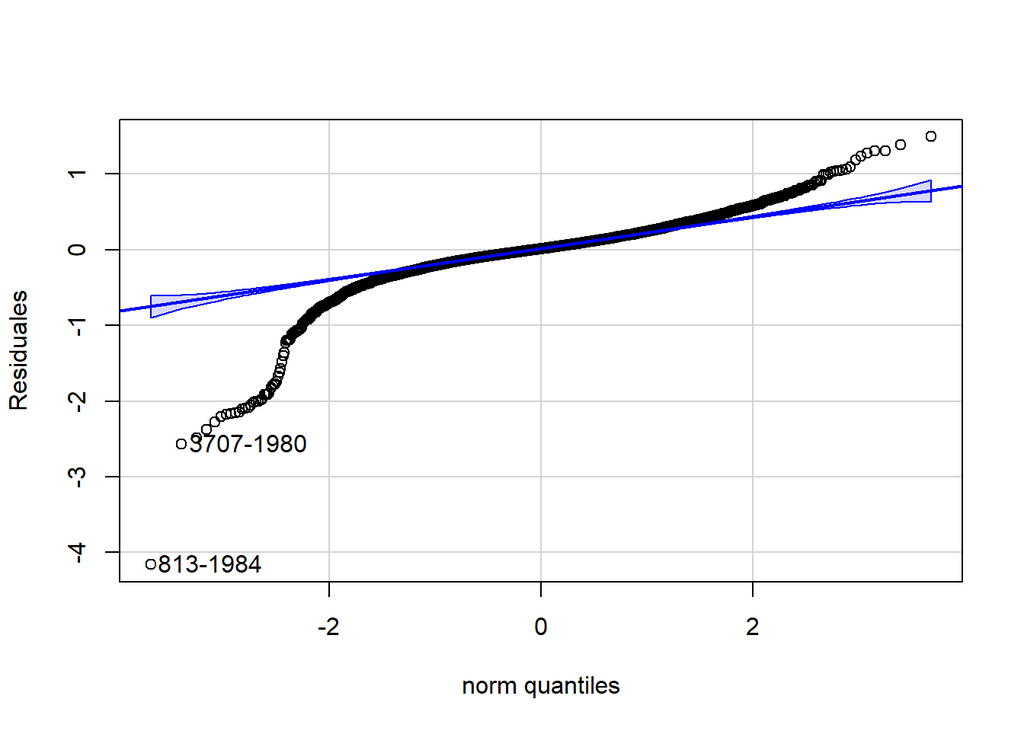

```
##  813-1984 3707-1980
##       325      1857
```

```r
Residuales=residuals(Fixed)
qqPlot(Residuales)
```

```r
jarque.bera.test(residuals(Fixed))
```

```
##
##  Jarque Bera Test
##
## data:  residuals(Fixed)
## X-squared = 52507, df = 2, p-value < 2.2e-16
```

Recordemos que este supuesto nos permite realizar inferencia estadística.

# 2. Subsidios y productividad laboral

## 2.1 Descripción y preparación

En este ejercicio se utiliza la base de datos JTRAIN.RAW para determinar el efecto del subsidio a la capacitación laboral en las horas de capacitación por empleado.

```r
data("jtrain")
attach(jtrain)
```

Como profesionales, tratamos los datos como una base de datos.

```r
panel.jtrain = pdata.frame(jtrain, index = c("fcode","year"))
```

Además, observamos sus características principales.

```r
View(jtrain)
pdim(panel.jtrain)
```

```
## Balanced Panel: n = 157, T = 3, N = 471
```

```r
pvar(panel.jtrain)
```

```
## no time variation:       fcode union lscrap_1 clscrap clemploy clsales clavgsal cgrant_1 chrsemp clhrsemp
## no individual variation: year employ sales avgsal scrap rework tothrs d89 d88 totrain hrsemp lscrap lemploy lsales lrework lhrsemp lscrap_1 clscrap clemploy clsales lavgsal clavgsal chrsemp clhrsemp
## all NA in time dimension for at least one individual:  employ sales avgsal scrap rework tothrs totrain hrsemp lscrap lemploy lsales lrework lhrsemp lscrap_1 clscrap clemploy clsales lavgsal clavgsal cgrant_1 chrsemp clhrsemp
## all NA in ind. dimension for at least one time period: employ sales avgsal scrap rework tothrs totrain hrsemp lscrap lemploy lsales lrework lhrsemp lscrap_1 clscrap clemploy clsales lavgsal clavgsal cgrant_1 chrsemp clhrsemp
```

Creamos una dummy temporal para recoger el impacto de cada año.

```r
years <- factor(panel.jtrain$year)
```

## 2.2 Estimación de modelos

Para este caso, consideraremos MCO combinados, efectos temporales e individuales.

```r
Pool.jtrain = plm(hrsemp~grant + grant_1 + lemploy,
                  data=panel.jtrain, model="pooling", effect = "twoways")


Pool.E1 =plm(hrsemp~ grant + grant_1 + lemploy + factor(year)+factor(fcode),
            data=panel.jtrain, model="pooling")

Pool.E2= lm(hrsemp~ grant + grant_1 + lemploy + factor(year)+factor(fcode),
             data = panel.jtrain)
```

Finalmente recogemos los resultados en una tabla de Stargazer.

```r
stargazer(Pool.jtrain, Pool.E1, Pool.E2,
          keep = c("grant", "gran_1", "lemploy","constant"),type = "text", style = "AER")
```

```
##
## =============================================================================================
##                                                      hrsemp
##                                          panel                                 OLS
##                                          linear
##                               (1)                     (2)                      (3)
## ---------------------------------------------------------------------------------------------
## grant                      33.337***               34.228***                34.228***
##                             (3.194)                 (2.858)                  (2.858)
##
## grant_1                      0.790                   0.504                    0.504
##                             (4.006)                 (4.127)                  (4.127)
##
## lemploy                    -4.629***                 -0.176                   -0.176
##                             (1.081)                 (4.288)                  (4.288)
##
## Observations                  390                     390                      390
## R2                           0.247                   0.802                    0.802
## Adjusted R2                  0.241                   0.691                    0.691
## Residual Std. Error                                                     14.283 (df = 250)
## F Statistic         42.280*** (df = 3; 386) 7.269*** (df = 139; 250) 7.269*** (df = 139; 250)
## ---------------------------------------------------------------------------------------------
## Notes:              ***Significant at the 1 percent level.
##                     **Significant at the 5 percent level.
##                     *Significant at the 10 percent level.
```